# Matrices de transición

12 de abril de 2018

## Contenido

- Matrices de transición
- Ejercicio 1.
- Solución de Tarea 04
- Presentación del tema de Trabajo individual
- Dudas con sesión de **Git**
- Dudas con Tarea 03
- Metas para la próxima semana

## Matrices de transición

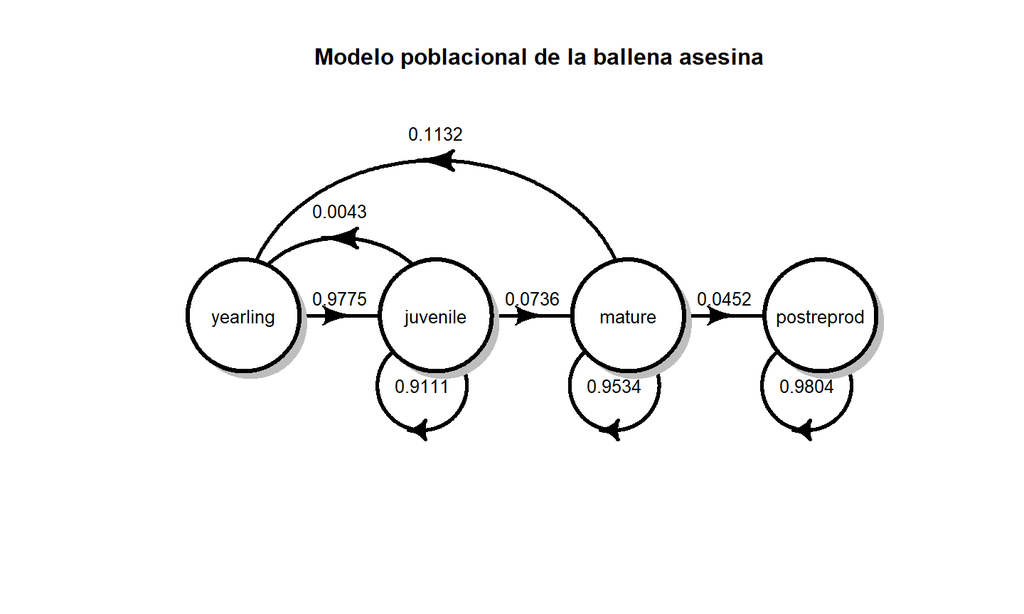

## Matrices de transición

- Tenemos una población con etapas
- La supervivencia se asocia mejor con las etapas, que con el tiempo
- Existe permanencia en una etapa
- También pueden usarse con clases de edad
- Representa la proporción de individuos que pasan de una etapa a la siguiente. A veces se habla de probabilidades, sin embargo, en la fecundidad la proporción de individuos de una clase adulta a una temprana puede ser mayor a uno.

## Ejemplo de una MT para la orca

Matriz de transición para la ballena asesina.

|  |  |  | Desde etapa |  |  |
| --- | --- | --- | --- | --- | --- |
|  |  | yearling | juvenile | mature | postreprod |
|  | yearling | 0.0000 | 0.0043 | 0.1132 | 0.0000 |
| Hasta etapa | juvenile | 0.9775 | 0.9111 | 0.0000 | 0.0000 |
|  | mature | 0.0000 | 0.0736 | 0.9534 | 0.0000 |
|  | postreprod | 0.0000 | 0.0000 | 0.0452 | 0.9804 |

## Como leer la matriz

Por covención, la etapa de referencia se ubica en las columas. Luego se ubica la etapa de transición en las filas.

¿Cuál es la probabilidad de pasar de juvenil a adulto?

¿Cuál es la probabilidad de pasar de adulto a juvenil?

¿Cuál es la probabilidad de pasar de adulto a yearling? ¿Qué significa?

## Proyección de la matriz a \(N_{t+1}\)

Vamos a llamar a esta matriz \(\mathbf{A}\).

Matriz de transición para la ballena asesina, expresada de manera simbólica.

|  | yearling | juvenile | mature | postreprod |
| --- | --- | --- | --- | --- |
| yearling |  | \(F_{jy}\) | \(F_{my}\) |  |
| juvenile | \(G_{yj}\) | \(P_{j}\) |  |  |
| mature |  | \(G_{jm}\) | \(P_m\) |  |
| postreprod |  |  | \(G_{mP}\) | \(P_P\) |

## Proyección de la matriz a \(N_{t+1}\)

Necesitamos un vector que contenga el número de individuos en el año (o unidad correspondiente) previo al que se desea proyectar. Es decir, si queremos proyectar a \(t+1\), debemos conocer el tamaño de población en el año \(t\).

\[ \mathbf{n}_t = \begin{pmatrix} n_y \\ n_j \\ n_m \\ n_P \end{pmatrix} \] Luego, representamos la operación como:

\[ \mathbf{n}_{t+1} = \mathbf{A}\mathbf{n}_t \]

## Proyección de la matriz a \(N_{t+1}\)

La expresión anterior es una forma corta de representar la multiplicación de matrices. Tanto los vectores como las matrices pueden ser representados en negrita; las matrices en mayúscula; los vectores en minúscula. Esta expresión simplifica la siguiente operación:

\[ \mathbf{n}_{t+1} = \begin{pmatrix} 0 & F_{jy} & F_{my} & 0 \\ G_{yj} & P_{j} & 0 & 0 \\ 0 & G_{jm} & P_m & 0 \\ 0 & 0 & G_{mP}& P_P \end{pmatrix} \times \begin{pmatrix} n_y \\ n_j \\ n_m \\ n_P \end{pmatrix} \]

## Proyección de la matriz a \(N_{t+1}\)

Desarrollar la multiplicación

\[ \mathbf{n}_{t+1} = \begin{pmatrix} 0\cdot n_y + F_{jy}\cdot n_j + F_{my}\cdot n_m + 0\cdot n_P \\ G_{yj}\cdot n_y + P_{j}\cdot n_j + 0\cdot n_m + 0\cdot n_P \\ 0\cdot n_y + G_{jm}\cdot n_j + P_m\cdot n_m + 0\cdot n_P \\ 0\cdot n_y + 0\cdot n_j + G_{mP}\cdot n_m + P_P\cdot n_P \end{pmatrix} \]

## Ejercicio 1.

*Hacer una proyección a \(t+1\) con la matriz de transición de la ballena asesina*

Vamos a asumir que se realizó un censo poblacional. Los resultados del censo fueron:

\[ \mathbf{n}_t = \begin{pmatrix} 123 \\ 87 \\ 60 \\ 64 \end{pmatrix} \]

Usar la matriz de transición de la ballena orca, y calcular \(n_{t+1}\):

## Solución

\[ \mathbf{n}_{t+1} = \begin{pmatrix} 0\cdot 123 + 0.0043 \cdot 87 + 0.1132\cdot 60 + 0\cdot 64 \\ 0.9775\cdot 123 + 0.9111\cdot 87+ 0\cdot 60+ 0\cdot 64 \\ 0\cdot 123 + 0.0736 \cdot 87 + 0.9534\cdot 60 + 0\cdot 64 \\ 0\cdot 123 +0\cdot 87 + 0.0452\cdot 60 + 0.9804\cdot 64 \end{pmatrix} \]

El resultado es:

\[ \mathbf{n}_{t+1} = \begin{pmatrix} 7.17 \\ 199.5 \\ 63.6 \\ 65.5 \end{pmatrix} \]

## Solución en **R**

```r
library(popbio)
data(whale)

nt <- c(123, 87, 60, 64)

ntp1 <- whale%*%nt # el '%*%'representa el operador para multiplicar
                    # matrices en R

ntp1
```

```
##                [,1]
## yearling     7.1661
## juvenile   199.4982
## mature      63.6072
## postreprod  65.4576
```

```r
#limpiar
detach("package:popbio", unload = TRUE)
rm(whale, ntp1, nt)
```

## Solución de Tarea 04

## Presentación del tema de Trabajo individual

## Dudas con sesión de **Git**

## Dudas con Tarea 03

## Metas para la próxima semana

- Meta de avance 1, del trabajo grupal
- Presentar evidencia de la Tarea 03